# DV_RProject1

Kayne Khoury, Zareen Khayrattee, Juanito Taveras

September 15, 2015

# Plot 1

SQL: select * from titanic

We plotted AGE onto the x-axis and FARE onto the y-axis. The color correlates to sex. We set the value “point” to the geom parameter so that our each record in our database would show up as one point.All of the data is used in this plot.From the plot, we can see that it looks like a vast majority of the people on the Titanic had a fare of less than 100.

```
##
## > require("ggplot2")
```

```
##
## > require("RCurl")
```

```
##
## > require("jsonlite")
```

```
##
## > require("extrafont")
```

```
## Registering fonts with R
```

```
##
## > return
## .Primitive("return")
##
## > df <- data.frame(fromJSON(getURL(URLencode("129.152.144.84:5001/rest/native/?query=\"select * from titanic\""),
## +     httpheader = c(DB = "jdbc:ora ..." ... [TRUNCATED]
##
## > ggplot() + coord_cartesian() + scale_x_continuous() +
## +     scale_y_continuous() + labs(title = "Titanic") + labs(x = "AGE",
## +     y = paste("FARE ..." ... [TRUNCATED]
```

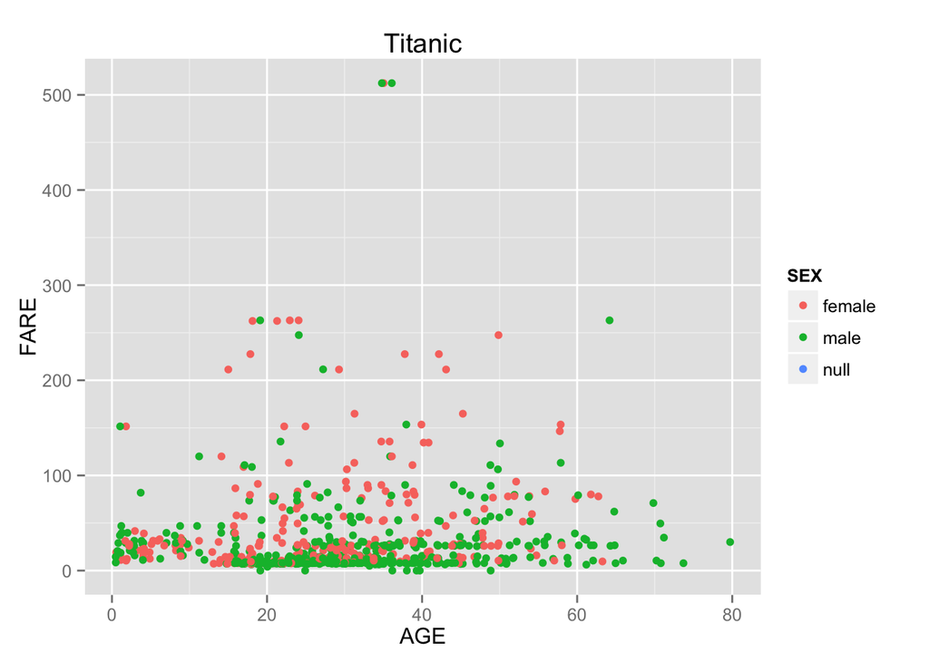

```r
source("../02 Visualizations/plot1.R",echo=TRUE)
```

# Plot 2

SQL: select * where from titanic where sex is not null

```
##
## > require("ggplot2")
##
## > require("RCurl")
##
## > require("jsonlite")
##
## > require("extrafont")
##
## > return
## .Primitive("return")
##
## > df <- data.frame(fromJSON(getURL(URLencode("129.152.144.84:5001/rest/native/?query=\"select * from titanic where sex is not null\""),
## +     httphea .... [TRUNCATED]
##
## > ggplot() + coord_cartesian() + scale_x_continuous() +
## +     scale_y_continuous() + labs(title = "Titanic") + labs(x = "Age",
## +     y = paste("Fare ..." ... [TRUNCATED]
```

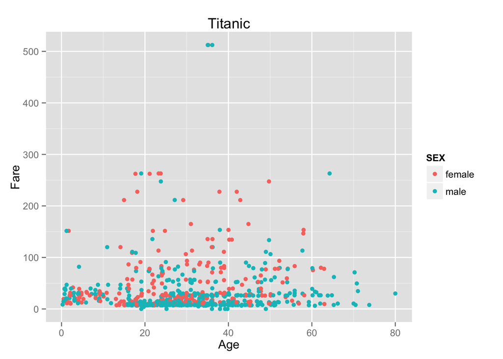

```r
source("../02 Visualizations/plot2.R",echo=TRUE)
```

# Plot 3

SQL: select * where from titanic where sex is not null

In this plot, we want to plot the number of males and females that survived against the cost of their fare. In this plot, the color of the dots indicates if the person representing the data point survived or not. From this plot, we can see that most of the females survived. Out of the females that perished, a vast majority of them had a lower fare and may have been lower class. We can also see that the majority of the males on the Titanic perished.

```
##
## > require("ggplot2")
##
## > require("RCurl")
##
## > require("jsonlite")
##
## > require("extrafont")
##
## > return
## .Primitive("return")
##
## > df <- data.frame(fromJSON(getURL(URLencode("129.152.144.84:5001/rest/native/?query=\"select * from titanic where sex is not null\""),
## +     httphea .... [TRUNCATED]
##
## > ggplot() + coord_cartesian() + scale_x_discrete() +
## +     scale_y_continuous() + labs(title = "Titanic") + labs(x = "Survived",
## +     y = paste("F ..." ... [TRUNCATED]
```

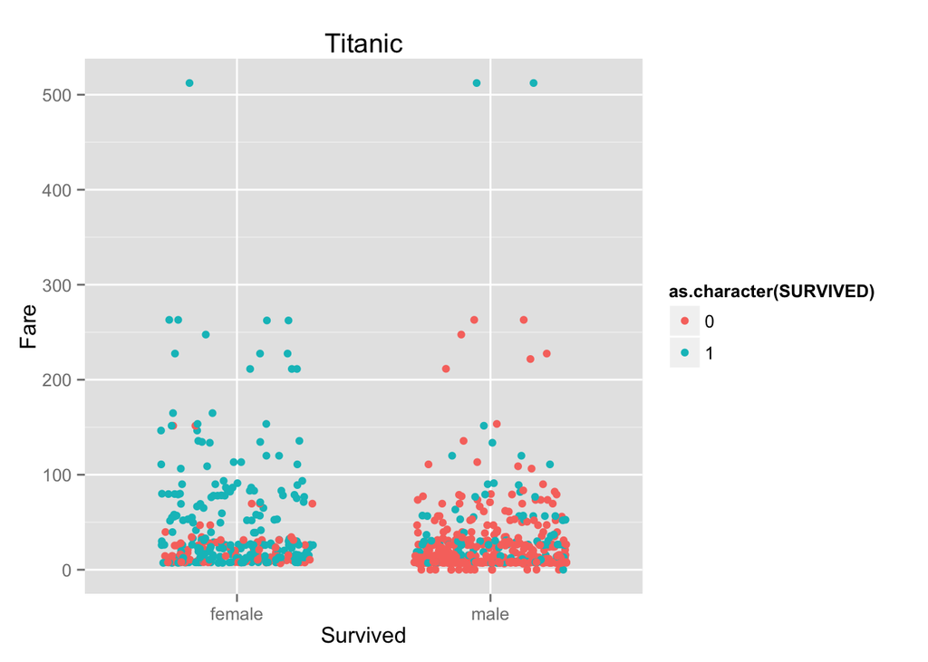

```r
source("../02 Visualizations/plot3.R",echo=TRUE)
```

# Plot 4

SQL: select * where from titanic where sex is not null

This plot introduced facets. There are 6 facets that each tell a different story. The 3 facets on the left, show the plots of the people who perished against their fare, and each facet is filtered for a particular PCLASS. The right 3 facets are the same but for the pepole who survived. From this plot we can see many interesting things, such as the vast majority of the females in PCLASS 1 survived.

```
##
## > require("ggplot2")
##
## > require("RCurl")
##
## > require("jsonlite")
##
## > require("extrafont")
##
## > return
## .Primitive("return")
##
## > df <- data.frame(fromJSON(getURL(URLencode("129.152.144.84:5001/rest/native/?query=\"select * from titanic where sex is not null\""),
## +     httphea .... [TRUNCATED]
##
## > ggplot() + coord_cartesian() + scale_x_discrete() +
## +     scale_y_continuous() + facet_grid(PCLASS ~ SURVIVED, labeller = label_both) +
## +     labs .... [TRUNCATED]
```

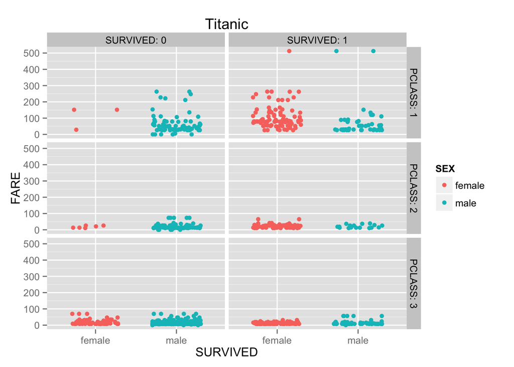

```r
source("../02 Visualizations/plot4.R",echo=TRUE)
```

# Plot 5

SQL: select * where from titanic where sex is not null and age <= 10

This plot has a similar structure as the plot above with the same facets, but the data only includes children ages 10 and under. From this data, you can see that almost all of the children from the upper 2 classes (PCLASS 1 and PCLASS 2) survived. The children that did perish were almost all in PCLASS 3, which tells a very sad story.

```
##
## > require("ggplot2")
##
## > require("RCurl")
##
## > require("jsonlite")
##
## > require("extrafont")
##
## > return
## .Primitive("return")
##
## > df <- data.frame(fromJSON(getURL(URLencode("129.152.144.84:5001/rest/native/?query=\"select * from titanic where sex is not null and age <=10\""),
##  .... [TRUNCATED]
##
## > ggplot() + coord_cartesian() + scale_x_discrete() +
## +     scale_y_continuous() + facet_grid(PCLASS ~ SURVIVED, labeller = label_both) +
## +     labs .... [TRUNCATED]
```

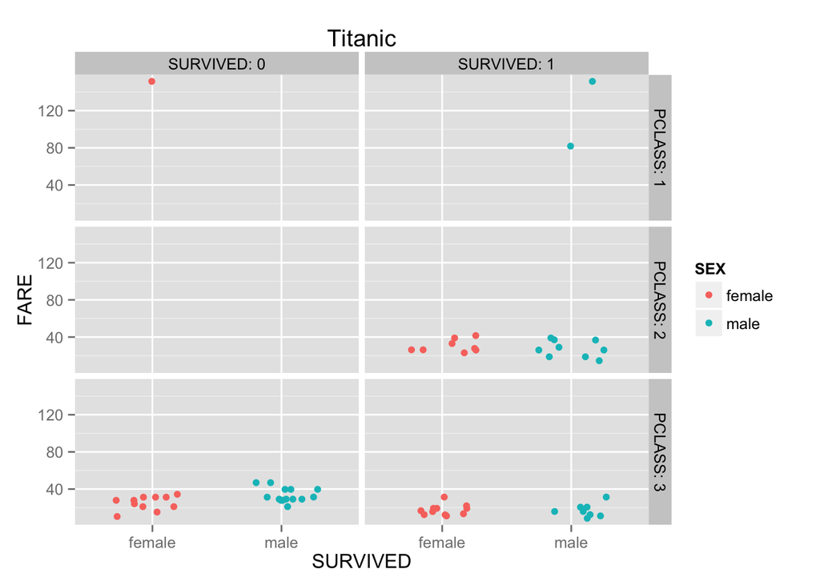

```r
source("../02 Visualizations/plot5.R",echo=TRUE)
```

# Plot 6

SQL: select * where from titanic where sex is not null and age > 50

In contrast to the plot above, we thought it would be interesting focus on the opposite end of the spectrum: people over the age of 50, so we filtered our data for those points. We only had one facet, divided it into 2 plots based on survival. From this plot, you can see that out of the people over the age of 50 who died, almost all of them were male. Very little males survived. It’s also interesting to note that most of them had a fare below 100, yet almost all of the females survived.

```
##
## > require("ggplot2")
##
## > require("RCurl")
##
## > require("jsonlite")
##
## > require("extrafont")
##
## > return
## .Primitive("return")
##
## > df <- data.frame(fromJSON(getURL(URLencode("129.152.144.84:5001/rest/native/?query=\"select * from titanic where sex is not null and age >50\""),
## + .... [TRUNCATED]
##
## > ggplot() + coord_cartesian() + scale_x_continuous() +
## +     scale_y_continuous() + facet_grid(~SURVIVED, labeller = label_both) +
## +     labs(title .... [TRUNCATED]
```

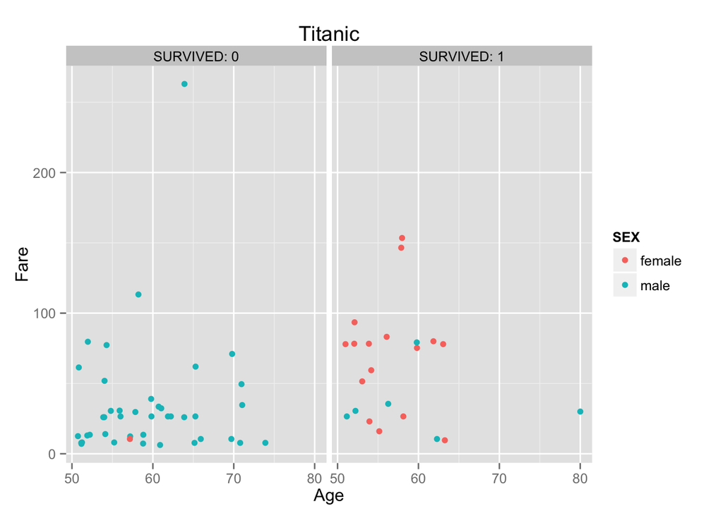

```r
source("../02 Visualizations/plot6.R",echo=TRUE)
```

# Summary

SQL: select * where from titanic where sex is not null

```r
source("../01 Data/summary.R",echo=TRUE)
```

```
##
## > df <- data.frame(fromJSON(getURL(URLencode("129.152.144.84:5001/rest/native/?query=\"select * from titanic where sex is not null\""),
## +     httphea .... [TRUNCATED]
##
## > summary(df)
##   PASSENGERID       SURVIVED          PCLASS
##  Min.   :  1.0   Min.   :0.0000   Min.   :1.000
##  1st Qu.:223.5   1st Qu.:0.0000   1st Qu.:2.000
##  Median :446.0   Median :0.0000   Median :3.000
##  Mean   :446.0   Mean   :0.3838   Mean   :2.309
##  3rd Qu.:668.5   3rd Qu.:1.0000   3rd Qu.:3.000
##  Max.   :891.0   Max.   :1.0000   Max.   :3.000
##
##                                     NAME         SEX           AGE
##  Abbing, Mr. Anthony                  :  1   female:314   null   :177
##  Abbott, Mr. Rossmore Edward          :  1   male  :577   24     : 30
##  Abbott, Mrs. Stanton (Rosa Hunt)     :  1                22     : 27
##  Abelson, Mr. Samuel                  :  1                18     : 26
##  Abelson, Mrs. Samuel (Hannah Wizosky):  1                19     : 25
##  Adahl, Mr. Mauritz Nils Martin       :  1                28     : 25
##  (Other)                              :885                (Other):581
##      SIBSP           PARCH             TICKET         FARE
##  Min.   :0.000   Min.   :0.0000   1601    :  7   Min.   :  0.00
##  1st Qu.:0.000   1st Qu.:0.0000   347082  :  7   1st Qu.:  7.91
##  Median :0.000   Median :0.0000   CA. 2343:  7   Median : 14.45
##  Mean   :0.523   Mean   :0.3816   3101295 :  6   Mean   : 32.20
##  3rd Qu.:1.000   3rd Qu.:0.0000   347088  :  6   3rd Qu.: 31.00
##  Max.   :8.000   Max.   :6.0000   CA 2144 :  6   Max.   :512.33
##                                   (Other) :852
##          CABIN     EMBARKED
##  null       :687   C   :168
##  B96 B98    :  4   null:  2
##  C23 C25 C27:  4   Q   : 77
##  G6         :  4   S   :644
##  C22 C26    :  3
##  D          :  3
##  (Other)    :186
```

# Subset

SQL: select * where from titanic where sex is not null

```r
source("../01 Data/subset.R",echo=TRUE)
```

```
##
## > df <- data.frame(fromJSON(getURL(URLencode("129.152.144.84:5001/rest/native/?query=\"select * from titanic where sex is not null\""),
## +     httphea .... [TRUNCATED]
##
## > tail(subset(df, select = c(FARE, SEX)))
##         FARE    SEX
## 886  41.5792 female
## 887 153.4625 female
## 888  31.2750 female
## 889   7.0500   male
## 890  15.5000 female
## 891   7.7500   male
```